# Modelagem Preditiva Avançada

Lista 1 - Diego Silva

# Exercício 1

> Apresente a análise da Atividade Integradora do trimestre passado usando o tidymodels. Não é necessário reproduzir todos os passos e ajustar todos os modelos, considere ajustar pelo menos 2 modelos preditivos fazendo a escolha de hiperparâmetros para avaliar o poder preditivo e decidir qual é o melhor modelo de acordo com uma métrica.

## Lendo o conjunto de dados

```r
df <- read_csv('data-treated.csv')
df$J1 <- as.factor(df$J1)

set.seed(123)
split <- initial_split(df, prop = .8, strata = "J1")

train <- training(split)
test <- testing(split)
```

## Criando os folds para validação cruzada que será utilizada posteriormente nos modelos

```r
cv_folds <- vfold_cv(train, v = 2)

cv_folds
```

| splits | id |
| --- | --- |
|  | Fold1 |
|  | Fold2 |

## Criando tabela para armazenar os resultados da análise

```r
results <- tibble(model = NA_character_, threshold = NA_integer_,  accuracy = NA_integer_, fbeta = NA_integer_, recall = NA, precision = NA_integer_)
```

## Definindo função para calculo das métricas para cada valor de corte

```r
cortes <- seq(0.01, 0.99, 0.01)

get_predictions_from_threshold <- function(threshold, df_gpft, model) {
  results <- df_gpft %>%
    mutate(threshold_preds = ifelse(df_gpft$.pred_1 >= threshold, 1, 0)) %>%
    mutate(observed = as.numeric(as.character(observed)), threshold_preds = as.numeric(as.character(threshold_preds)))

 tibble(
   model = model,
   fbeta = Metrics::fbeta_score(results$observed, results$threshold_preds),
   acc = Metrics::accuracy(results$observed, results$threshold_preds),
   precision = Metrics::precision(results$observed, results$threshold_preds),
   recall = Metrics::recall(results$observed, results$threshold_preds),
   threshold = threshold
   )
}
```

## Aplicação dos modelos

**Disclaimer*: A fins de prática, serão realizadas a receita e sua preparação em todas as etapas.*

### LASSO

- Preparando a receita para o lasso

```r
lasso_recipe <- recipe(J1 ~ ., data = train)

lasso_prep <- prep(lasso_recipe)

lasso_juiced <- bake(lasso_prep, new_data = NULL)

lasso_baked <- bake(lasso_prep, new_data = test)
```

- Definição do Modelo

```r
lasso <- logistic_reg(penalty = tune(), mixture = 1) %>%
  set_engine("glmnet") %>%
  set_mode("classification")
```

- Visualizando a especificação

```r
lasso
```

```
## Logistic Regression Model Specification (classification)
##
## Main Arguments:
##   penalty = tune()
##   mixture = 1
##
## Computational engine: glmnet
```

- Realizando o tunning

```r
tune_lasso <- tune_grid(
  lasso,
  lasso_recipe,
  resamples = cv_folds,
  grid = 1,
  metrics = metric_set(roc_auc, yardstick::accuracy, yardstick::specificity, yardstick::sensitivity, yardstick::f_meas)
  )
```

- Visualizando as métricas do tune_grid em relação a regularização:

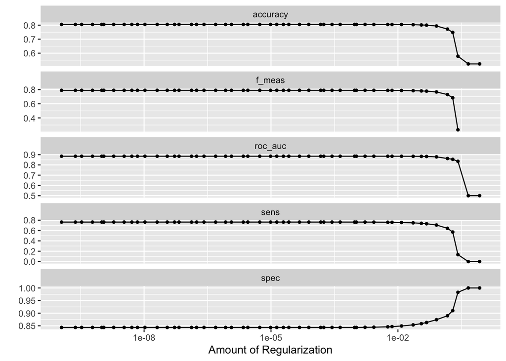

```r
autoplot(tune_lasso)
```

Selecionando a quantidade de regularização pelos valores obtidos da curva roc e f1:

```r
best_lasso <- tune_lasso %>%
  select_best("roc_auc", "f_meas")
```

Ajustando o modelo final:

```r
fitted_lasso <- finalize_model(lasso, parameters = best_lasso) %>%
  fit(J1 ~ ., data=lasso_juiced)
```

Obtendo os resultados e salvando-os para cada valor de corte

```r
lasso_results <- fitted_lasso %>%
  predict(new_data = lasso_baked, type = "prob") %>%
  mutate(observed = lasso_baked$J1, model = "lasso")

results <- results %>%
  bind_rows(map(cortes, get_predictions_from_threshold, df_gpft = lasso_results, model = "lasso")) %>%
  arrange(desc(fbeta))
```

### Regressão logística

Preparando a receita para a aplicação do modelo logístico

```r
lr_recipe <- recipe(J1 ~ ., train) %>% # define a receita, com a variavel resposta e os dados de treinamento
  step_normalize(all_numeric())

lr_prep <- prep(lr_recipe)# prepara a receita definida acima

lr_juiced <- juice(lr_prep) # obtem os dados de treinamento processados

baked_test <- bake(lr_prep, new_data = test) # obtem os dados de teste processados
```

```r
lr_fit <- logistic_reg() %>%
  set_engine("glm") %>%
  fit(J1 ~ ., lr_juiced) %>%
  set_mode("classification")


lr_results <- lr_fit %>%
  predict(new_data = baked_test, type = "prob") %>%
  mutate(observed = test$J1, modelo = "logistic regression")

results <- results %>%
  bind_rows(map(cortes, get_predictions_from_threshold, df_gpft = lr_results, model = 'lr'))
```

### Árvore de Decisão

Para a Árvore de Decisão, iremos realizar o *tuning* dos parâmetros para avaliarmos o seu poder preditivo e aplicaremos validação cruzada para estimarmos o erro de classificação.

```r
tree_recipe <- recipe(J1 ~ ., train) %>%
  step_normalize(all_numeric())

tree_prep <- prep(tree_recipe)

tree_juiced <- bake(tree_prep, new_data = NULL)

tree_baked <- bake(tree_prep, new_data = test)
```

Após a preparação da receita, iremos criar e ajustar a árvore de decisão tunada.

Adicionando paralelismo

```r
doParallel::registerDoParallel(cores = 4)
```

> Especificando a árvore de decisão tunada

```r
tree <- decision_tree(
  tree_depth = tune(),
  cost_complexity = tune()) %>%
  set_engine("rpart") %>%
  set_mode("classification")

tree
```

```
## Decision Tree Model Specification (classification)
##
## Main Arguments:
##   cost_complexity = tune()
##   tree_depth = tune()
##
## Computational engine: rpart
```

> Tunando a árvore

```r
tune_tree <- tune_grid(
  tree,
  tree_recipe,
  resamples = cv_folds,
  grid = 1,
  metrics = metric_set(roc_auc, yardstick::accuracy, yardstick::specificity, yardstick::sensitivity, yardstick::f_meas)
  )

tune_tree$.notes
```

```
## [[1]]
## # A tibble: 0 x 1
## # … with 1 variable: .notes <chr>
##
## [[2]]
## # A tibble: 0 x 1
## # … with 1 variable: .notes <chr>
```

> Analisando o gráfico contendo as métricas e os valores obtidos para cada um dos valores assumidos para os hiperparâmetros tunados:

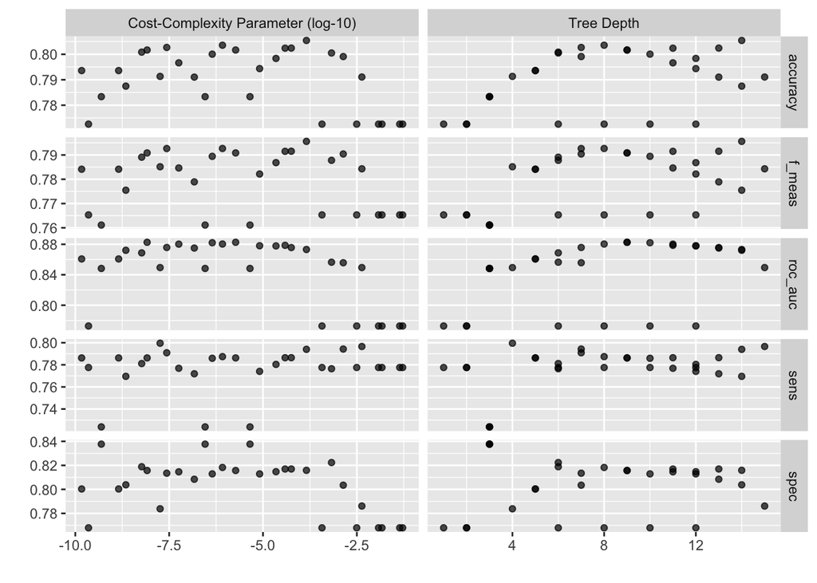

```r
autoplot(tune_tree)
```

> Coletando as métricas

```r
tune_tree %>%
  collect_metrics() %>%
  head(5)
```

[output not shown]

> Selecionando os melhores valores para os hiperparâmetros pela curva roc e salvando-os para ajustarmos o modelo final com os valores encontrados.

```r
best_tree <- tune_tree %>%
  select_best("roc_auc", "f_meas")
```

> Finalizando o modelo e obtendo as predictions para cada valor de corte. Adicionaremos também a tibble resultante a tibble dos nossos resultados.

```r
fit_tree <- finalize_model(tree, parameters = best_tree) %>%
  fit(J1 ~ ., data=train)

tree_preds <- fit_tree %>%
  predict(new_data = test, type = "prob") %>%
  mutate(observed = test$J1)

results <- results %>%
  bind_rows(map(cortes, get_predictions_from_threshold, df_gpft = tree_preds, model = 'tree'))
```

### Floresta Aleatória

Assim como na Árvore de Decisão, também realizaremos o tunning dos hiperparâmetros e validação cruzada para estimarmos o erro de classificação.

Começaremos pela receita:

```r
rf_recipe <- recipe(J1 ~ ., data = train)

rf_prep <- prep(rf_recipe)

rf_baked_train <- bake(rf_prep, new_data = NULL)

rf_baked_test <- bake(rf_prep, new_data = test)
```

Seguiremos agora para a especificação do modelo:

```r
dials::trees()
```

```
## # Trees (quantitative)
## Range: [1, 2000]
```

```r
rf <- rand_forest(
  mtry = tune(),
  trees = 10,
  min_n = tune()
) %>%
  set_engine("ranger") %>%
  set_mode("classification")

rf
```

```
## Random Forest Model Specification (classification)
##
## Main Arguments:
##   mtry = tune()
##   trees = 10
##   min_n = tune()
##
## Computational engine: ranger
```

> Tunando o modelo

```r
tune_rf <- tune_grid(
  rf,
  rf_recipe,
  resamples = cv_folds,
  grid = 1,
  control = control_grid(verbose = TRUE)
)
```

```
## i Creating pre-processing data to finalize unknown parameter: mtry
```

[output not shown]

[output not shown]

[output not shown]

[output not shown]

[output not shown]

[output not shown]

[output not shown]

[output not shown]

[output not shown]

[output not shown]

```r
tune_rf
```

| splits | id | .metrics | .notes |
| --- | --- | --- | --- |
|  | Fold1 |  |  |
|  | Fold2 |  |  |

> Selecionando o melhor modelo pela área abaixo da curva e f1

```r
best_rf <- tune_rf %>%
  select_best("roc_auc", "f_meas")
```

> Finalizando o modelo com os hiperparametros obtidos

```r
fit_rf <- finalize_model(rf, parameters = best_rf) %>%
  fit(J1 ~ ., data = train)
```

> Calculando as métricas de interesse para cada valor de corte

```r
rf_preds <-  fit_rf %>%
  predict(new_data = test, type="prob") %>%
  mutate(observed = rf_baked_test$J1, model = "rf")

results <- results %>%
  bind_rows(map(cortes, get_predictions_from_threshold, df_gpft = rf_preds, model = 'rf'))
```

```r
stopImplicitCluster()
```

```r
results
```

| model | threshold | accuracy | fbeta | recall | precision | acc |
| --- | --- | --- | --- | --- | --- | --- |
| lasso | 0.45 | NA | 0.8212654396 | 0.8726092700 | 0.7756279 | 0.8013458 |
| lasso | 0.46 | NA | 0.8209393346 | 0.8673826891 | 0.7792168 | 0.8020968 |
| lasso | 0.44 | NA | 0.8206520278 | 0.8768594567 | 0.7712164 | 0.7995434 |
| lasso | 0.48 | NA | 0.8206087962 | 0.8562403079 | 0.7878243 | 0.8041996 |
| lasso | 0.49 | NA | 0.8204957762 | 0.8507265522 | 0.7923398 | 0.8053111 |
| lasso | 0.47 | NA | 0.8203823747 | 0.8613520188 | 0.7831332 | 0.8027276 |
| lasso | 0.43 | NA | 0.8198744490 | 0.8813968181 | 0.7663803 | 0.7974406 |
| lasso | 0.50 | NA | 0.8195999777 | 0.8449256217 | 0.7957484 | 0.8054613 |
| lasso | 0.42 | NA | 0.8195894085 | 0.8862213543 | 0.7622765 | 0.7959386 |
| lasso | 0.41 | NA | 0.8193923382 | 0.8906438458 | 0.7586966 | 0.7946469 |

[output cut: 387 more lines]

# Exercício 2

Considere um modelo linear com todas as variáveis preditoras e um modelo linear com 5 componentes principais para previsão do valor mediano dos imóveis do banco de dados Boston (acesse com MASS::Boston ). Para avaliar o desempenho dos modelos, faça uma divisão dos dados de 80% para treinamento e o restante para teste. Indique qual métrica está sendo utilizada para a comparação dos modelos e defina o melhor modelo preditivo. Dicas: Note que queremos predizer o valor mediano dos imóveis, não médio. O que isso muda em nossa avaliação? Para comparar o modelo sem PCA e com PCA, você pode usar tune() no número de componentes e, na tune_grid() adicionar os valores 0 e 4. O valor zero fará com que o PCA não seja ajustado, enquanto que o valor 4 considerará 4 componentes principais.

Carregaremos o dataset e veremos a distribuição dos valores obtidos em cada uma das colunas

```r
df <- MASS::Boston
summary(df)
```

```
##       crim                zn             indus            chas
##  Min.   : 0.00632   Min.   :  0.00   Min.   : 0.46   Min.   :0.00000
##  1st Qu.: 0.08205   1st Qu.:  0.00   1st Qu.: 5.19   1st Qu.:0.00000
##  Median : 0.25651   Median :  0.00   Median : 9.69   Median :0.00000
##  Mean   : 3.61352   Mean   : 11.36   Mean   :11.14   Mean   :0.06917
##  3rd Qu.: 3.67708   3rd Qu.: 12.50   3rd Qu.:18.10   3rd Qu.:0.00000
##  Max.   :88.97620   Max.   :100.00   Max.   :27.74   Max.   :1.00000
##       nox               rm             age              dis
##  Min.   :0.3850   Min.   :3.561   Min.   :  2.90   Min.   : 1.130
##  1st Qu.:0.4490   1st Qu.:5.886   1st Qu.: 45.02   1st Qu.: 2.100
##  Median :0.5380   Median :6.208   Median : 77.50   Median : 3.207
##  Mean   :0.5547   Mean   :6.285   Mean   : 68.57   Mean   : 3.795
##  3rd Qu.:0.6240   3rd Qu.:6.623   3rd Qu.: 94.08   3rd Qu.: 5.188
##  Max.   :0.8710   Max.   :8.780   Max.   :100.00   Max.   :12.127
##       rad              tax           ptratio          black
##  Min.   : 1.000   Min.   :187.0   Min.   :12.60   Min.   :  0.32
##  1st Qu.: 4.000   1st Qu.:279.0   1st Qu.:17.40   1st Qu.:375.38
##  Median : 5.000   Median :330.0   Median :19.05   Median :391.44
##  Mean   : 9.549   Mean   :408.2   Mean   :18.46   Mean   :356.67
##  3rd Qu.:24.000   3rd Qu.:666.0   3rd Qu.:20.20   3rd Qu.:396.23
##  Max.   :24.000   Max.   :711.0   Max.   :22.00   Max.   :396.90
##      lstat            medv
##  Min.   : 1.73   Min.   : 5.00
##  1st Qu.: 6.95   1st Qu.:17.02
##  Median :11.36   Median :21.20
##  Mean   :12.65   Mean   :22.53
##  3rd Qu.:16.95   3rd Qu.:25.00
##  Max.   :37.97   Max.   :50.00
```

Separando os dados em treino e teste, e então criando os *cross-validation folds*

```r
set.seed(1232)

splits <- initial_split(df, prop = .8, strata = "medv")

train <- training(splits)
test <- testing(splits)

cv_folds <- vfold_cv(train, v = 2)
```

Definindo tibble para armazenar os resultados obtidos por cada modelo em relação a métrica de interesse:

```r
results <- tibble(model = NA, mae = NA_integer_)
```

## Regressão Linear

Preparando a receita:

```r
# escolher colunas a serem aplicadas pca
lm_recipe <- recipe(medv ~ ., data = train) %>%
  step_normalize(all_numeric(), -all_outcomes()) %>%
  step_pca(c(where(is.numeric), -age, -all_outcomes()), num_comp = 4)

lm_prep <- prep(lm_recipe)

train_lm <- bake(lm_prep, new_data = NULL)

test_lm <- bake(lm_prep, new_data = test)
```

```r
lm_fit <- linear_reg() %>%
  set_engine("lm")

lm_fitted <- lm_fit %>%
  fit(medv ~ ., data = train_lm)
```

Obtendo as previsões e o *MAE* do modelo linear ajustado e salvando-as no tibble de resultados:

```r
results <- results %>%
  bind_rows(
    tibble(
      model = "lm",
      mae = Metrics::mae(test_lm$medv, predict(lm_fitted, test_lm)$.pred)
      )
    )
```

## LASSO

Preparando a receita para o modelo LASSO:

```r
lasso_recipe <- recipe(medv ~ ., data = train) %>%
  step_normalize(all_numeric(), -all_outcomes())  %>%
  step_pca(c(where(is.numeric), -age, -all_outcomes()), num_comp = tune())

lasso_train <- bake(lasso_prep, new_data = NULL)

lasso_test <- bake(lasso_prep, new_data = test)
```

Definição do modelo e do workflow:

```r
lasso_fit <- linear_reg(
  penalty = tune(),
  mixture = 1
) %>%
  set_engine("glmnet") %>%
  set_mode("regression")

lasso_workflow <- workflow() %>%
  add_model(lasso_fit) %>%
  add_recipe(lasso_recipe)
```

Tunando a regularização utilizando validação cruzada:

```r
lasso_grid <- dials::grid_regular(
  penalty(),
  num_comp(c(0L, 4L)),
  levels = 2
)

lasso_tuned <- lasso_workflow %>%
  tune_grid(
    cv_folds,
    grid = lasso_grid,
    control_grid = control_grid(verbose = TRUE, save_pred = TRUE),
    metrics = metric_set(yardstick::mae)
  )
```

- Visualizando o gráfico com os resultados:

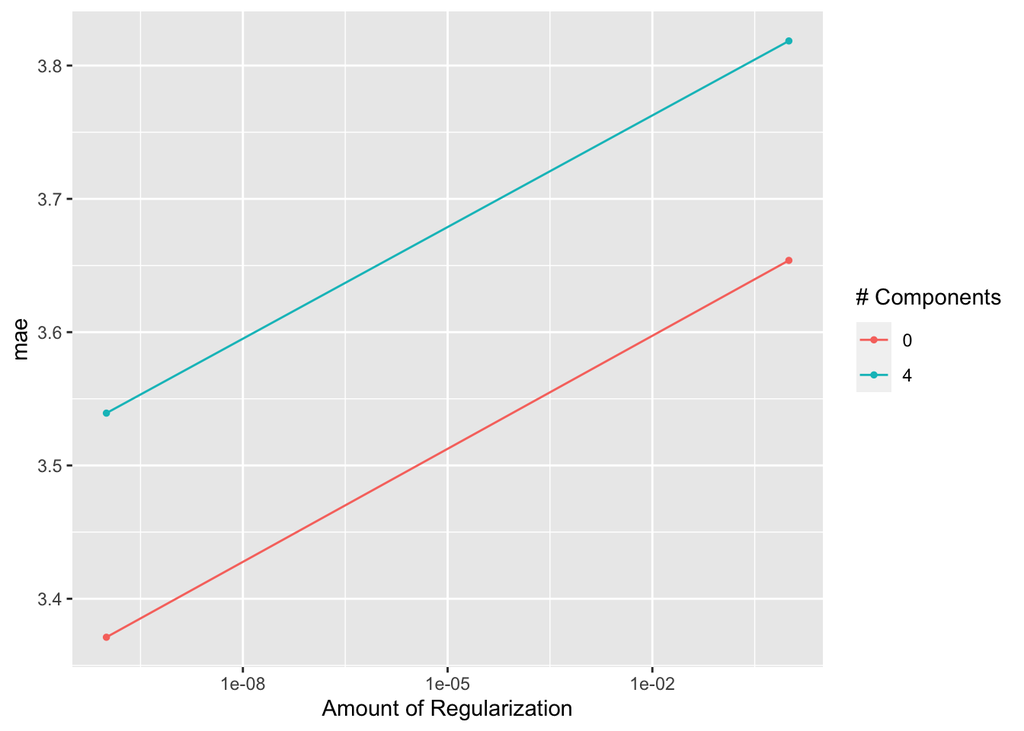

```r
autoplot(lasso_tuned)
```

Selecionando a regularização pelo melhor valor obtido de *MAE*:

```r
best_lasso <- lasso_tuned %>%
  select_best("mae")

best_lasso
```

| penalty | num_comp | .config |
| --- | --- | --- |
| 1e-10 | 0 | Preprocessor1_Model1 |

Finalizando o modelo lasso:

```r
final_lasso <- finalize_model(lasso_fit, parameters = best_lasso) %>%
  fit(medv ~ ., data = train)
```

Estimando o *MAE* do modelo lasso ajustado e salvado-o em nosso *tibble* de resultados:

```r
results <- results %>%
  bind_rows(tibble(model = "lasso", mae = Metrics::mae(test$medv, predict(final_lasso, test)$.pred)))
```

## Ridge

Preparando a receita:

```r
ridge_recipe <- recipe(medv ~ ., data = train) %>%
  step_normalize(all_numeric(), -all_outcomes()) %>%
  step_pca(c(where(is.numeric), -age, -all_outcomes()), num_comp = tune())
```

Definindo o modelo e do workflow:

```r
ridge_fit <- linear_reg(
  penalty = tune(),
  mixture = 0
  ) %>%
  set_engine("glmnet") %>%
  set_mode("regression")


ridge_workflow <- workflow() %>%
  add_model(ridge_fit) %>%
  add_recipe(ridge_recipe)
```

Realizando validação cruzada:

```r
ridge_grid <- dials::grid_regular(
  penalty(),
  num_comp(c(0L, 5L)),
  levels = 2
)


ridge_tuned <- ridge_workflow %>%
  tune_grid(
    resamples = cv_folds,
    grid = ridge_grid,
    metrics = metric_set(yardstick::mae),
    control = control_grid(verbose = TRUE, save_pred = TRUE)
  )
```

[output not shown]

[output not shown]

[output not shown]

[output not shown]

[output not shown]

[output not shown]

[output not shown]

[output not shown]

[output not shown]

[output not shown]

[output not shown]

[output not shown]

[output not shown]

[output not shown]

[output not shown]

[output not shown]

[output not shown]

[output not shown]

[output not shown]

[output not shown]

Visualizando o gráfico do *MAE* em relação a regularização no modelo ridge:

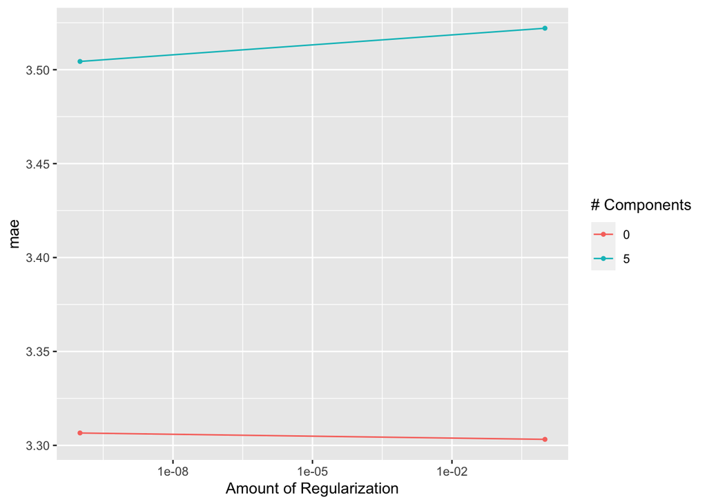

```r
autoplot(ridge_tuned)
```

Selecionando os valores de componentes com melhor *MAE* e salvando o *MAE* do modelo ridge obtido:

```r
best_ridge <- ridge_tuned %>%
  select_best()

final_ridge <- finalize_model(ridge_fit, parameters = best_ridge) %>%
  fit(medv ~ ., data = train)

results <- results %>%
  bind_rows(
    tibble(
      model = "ridge",
      mae = Metrics::mae(test$medv, predict(final_ridge, test)$.pred)
    )
  )
```

## Árvore de Decisão

Preparando a receita:

```r
tree_recipe <- recipe(medv ~ ., data = train) %>%
  step_normalize(all_numeric(), -all_outcomes()) %>%
  step_pca(c(where(is.numeric), -age, -all_outcomes()), num_comp = tune())
```

Definindo o modelo e o workflow:

```r
tree_fit <- decision_tree(
  tree_depth = 2,
  min_n = tune(),
  cost_complexity = tune()
) %>%
  set_engine("rpart") %>%
  set_mode("regression")



tree_workflow <- workflow() %>%
  add_model(tree_fit) %>%
  add_recipe(tree_recipe)
```

Tunando os hiperparâmetros do modelo utilizando validação cruzada:

```r
doParallel::registerDoParallel(4)

tuned_tree <- tree_workflow %>%
  tune_grid(
    resamples = cv_folds,
    metrics = metric_set(yardstick::mae)
  )


doParallel::stopImplicitCluster()
```

Visualizando os resultados *MAEs* obtidos para cada valor dos hiperparâmetros:

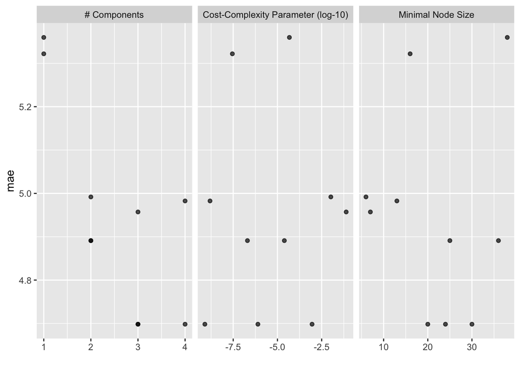

```r
autoplot(tuned_tree)
```

Selecionando os melhores valores, finalizando o modelo e guardando os resultados em nossa tibble:

```r
best_tree <- tuned_tree %>%
  select_best("mae")


final_tree <- finalize_model(tree_fit, parameters = best_tree) %>%
  fit(medv ~ ., train)


results <- results %>%
    bind_rows(
    tibble(
      model = "ridge",
      mae = Metrics::mae(test$medv, predict(final_tree, test)$.pred)
    )
  )
```

## Random Forest

Realizando todo o processo repetido anteriormente para cada um dos modelos abaixo:

```r
doParallel::registerDoParallel(4)

rf_recipe <- recipe(medv ~ ., data = train) %>%
  step_normalize(all_predictors(), -all_outcomes()) %>%
  step_pca(c(where(is.numeric), -age, -all_outcomes()), num_comp = tune())

rf_fit <- rand_forest(mtry = 3, min_n = tune(), trees = 10) %>%
  set_engine("ranger", num.threads = 4, importance = "impurity") %>%
  set_mode("regression")

rf_workflow <- workflow() %>%
  add_recipe(rf_recipe) %>%
  add_model(rf_fit)

rf_tuned <- rf_workflow %>%
  tune_grid(
    resamples = cv_folds,
    metrics = metric_set(yardstick::mae),
    control = control_grid(verbose = TRUE, save_pred = TRUE)
  )

doParallel::stopImplicitCluster()

best_rf <- rf_tuned %>%
  select_best("mae")

rf_final <- rf_workflow %>%
  finalize_workflow(best_rf) %>%
  last_fit(splits)

results <- results %>%
  bind_rows(
    tibble(
      model = 'rf',
      mae = Metrics::mae(rf_final$.predictions[[1]]$medv, rf_final$.predictions[[1]]$.pred)
    )
  )

results %>%
  arrange(mae, ascending = FALSE)
```

| model | mae |
| --- | --- |
| rf | 3.165746 |
| lasso | 3.445544 |
| ridge | 3.460799 |
| lm | 4.125169 |
| ridge | 4.672883 |
| NA | NA |

O melhor modelo ajustado foi o Random Forest. Iremos visualizar os valores dos hiperparâmetros do modelo ajustado:

```r
best_rf
```

| min_n | num_comp | .config |
| --- | --- | --- |
| 19 | 4 | Preprocessor3_Model1 |

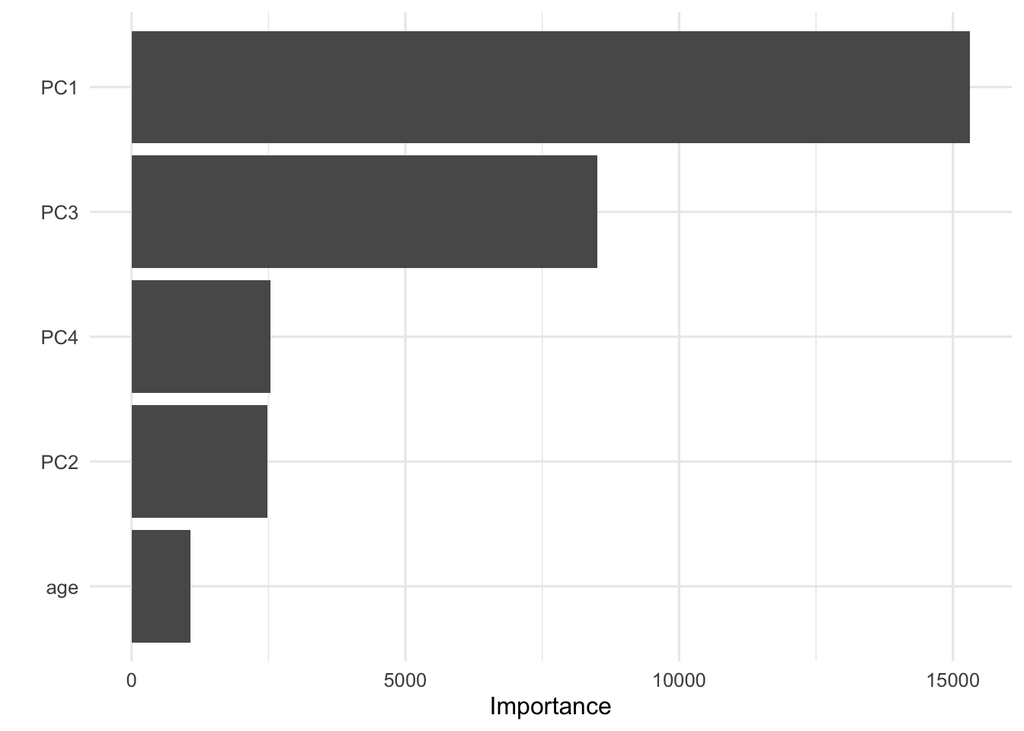

```r
rf_final %>%
  purrr::pluck(".workflow", 1) %>% # pega o modelo ajustado
  pull_workflow_fit() %>% # extrai o objeto do modelo
  vip::vip(num_features = 20) +
  theme_minimal(12)
```

# Exercício 3

Compare o desempenho preditivo de uma rede neural e de outro modelo de sua escolha na previsão da variável median_house_value (median house value for households within a block (measured in US Dollars)” do conjunto de dados “housing.csv”. A seguir são apresentadas as varáveis preditoras contidas nesse banco de dados:  
longitude : a measure of how far west a house is; a higher value is farther west latitude : a measure of how far north a house is; a higher value is farther north housing_median_age : median age of a house within a block; a lower number is a newer building total_rooms : total number of rooms within a block total_bedrooms : total number of bedrooms within a block population : total number of people residing within a block households : total number of households, a group of people residing within a home unit, for a block median_income : median income for households within a block of houses (measured in tens of thousands of US Dollars) median_house_value : median house value for households within a block (measured in US Dollars) ocean_proximity : location of the house w.r.t ocean/sea

Apresente os resultados e a explicação em formato de relatório. Mais detalhes sobre esse conjunto de dados podem ser obtidos em https://github.com/ageron/handson-ml/tree/master/datasets/housing (https://github.com/ageron/handson-ml/tree/master/datasets/housing)

## Lendo o conjunto de dados

```r
data <- read.csv('./housing.csv')

names(data)
```

```
##  [1] "longitude"          "latitude"           "housing_median_age"
##  [4] "total_rooms"        "total_bedrooms"     "population"
##  [7] "households"         "median_income"      "median_house_value"
## [10] "ocean_proximity"
```

## Descrevendo o nosso conjunto

```r
summary(data)
```

```
##    longitude         latitude     housing_median_age  total_rooms
##  Min.   :-124.3   Min.   :32.54   Min.   : 1.00      Min.   :    2
##  1st Qu.:-121.8   1st Qu.:33.93   1st Qu.:18.00      1st Qu.: 1448
##  Median :-118.5   Median :34.26   Median :29.00      Median : 2127
##  Mean   :-119.6   Mean   :35.63   Mean   :28.64      Mean   : 2636
##  3rd Qu.:-118.0   3rd Qu.:37.71   3rd Qu.:37.00      3rd Qu.: 3148
##  Max.   :-114.3   Max.   :41.95   Max.   :52.00      Max.   :39320
##
##  total_bedrooms     population      households     median_income
##  Min.   :   1.0   Min.   :    3   Min.   :   1.0   Min.   : 0.4999
##  1st Qu.: 296.0   1st Qu.:  787   1st Qu.: 280.0   1st Qu.: 2.5634
##  Median : 435.0   Median : 1166   Median : 409.0   Median : 3.5348
##  Mean   : 537.9   Mean   : 1425   Mean   : 499.5   Mean   : 3.8707
##  3rd Qu.: 647.0   3rd Qu.: 1725   3rd Qu.: 605.0   3rd Qu.: 4.7432
##  Max.   :6445.0   Max.   :35682   Max.   :6082.0   Max.   :15.0001
##  NA's   :207
##  median_house_value ocean_proximity
##  Min.   : 14999     Length:20640
##  1st Qu.:119600     Class :character
##  Median :179700     Mode  :character
##  Mean   :206856
##  3rd Qu.:264725
##  Max.   :500001
##
```

Há 207 `missing values` em total_bedrooms, iremos remove-los dos nossos dados para prosseguirmos com a construção e avaliação dos modelos

```r
data <- data %>%
  drop_na()
```

## Modelagem

```r
splits <- initial_split(data, strata = "median_house_value")

train <- training(splits)
test <- testing(splits)

cv_folds <- vfold_cv(train, v = 10)
```

```r
lasso_recipe <- recipe(median_house_value ~ ., data = train) %>%
  step_string2factor(all_nominal()) %>%
  step_normalize(all_numeric(), -latitude, -longitude, -median_house_value) %>%
  step_dummy(ocean_proximity) %>%
  step_pca(-all_outcomes(), -latitude, -longitude)
```